# Lab 2: Distance

## FRE 430 Spatial Data Science

##### Instructor: Jonathan Proctor

##### Teaching Assistant: Bhavita Ragoo

##### About this lab:

- Due date Jan. 20nd, 2026 at 9:30am.
- You may talk with other students about the lab, but each student is responsible for doing all exercises in the lab themselves and turning in their own write up. We will be checking code for evidence of copying and pasting.
- This is a newly developed assignment, so if you think there is an error or something is unclear, let us know right away. That will be extremely helpful to us and your fellow students.
- Submit your lab as both LASTNAME.html and LASTNAME.Rmd on canvas. Please re-run the entire notebook, as needed, prior to submitting to make sure the results show the output from the existing code.
- Thanks to Solomon Hsiang for sharing some materials this lab is based on.

## Objectives:

In this lab you will learn to load and save data, write for loops and functions, and calculate and use distances.

## 1. Assigning Families to Schools Using Distance

In this problem, you will determine which families should send their children to which school by calculating which school is closest to each family’s home (we want to minimize travel time). You will be given data on household locations and data on school locations.

## 1.1. Notation

Before we get started, we are going to need to think through a way to efficiently store house locations. If we store each house’s x and y location as a variable, then we’d need six variables to describe the locations of three houses. That’s not going to scale well. Because we are in a two-dimensional system, we know that we will always need at least six *numbers* to describe the locations of all three houses, but if we organize these six numbers differently (in terms of how we store them in R) we can make our lives much easier, from a programming standpoint. In most data sets that describe many individual objects (e.g., houses), there is a single vector that describes *all* the x locations for multiple objects and a single vector that describes all the y locations for those same objects. Within this vector we keep track of which object (house) is associated with which element of the vector by using the index of the element to uniquely identify the object. In this small data set of houses, we would do this by combining the x and y locations into vectors

$$\overrightarrow{x} = \left[
\begin{array}{c} house0\_x \\ house1\_x \\ house2\_x \end{array}
\right]~, \quad \overrightarrow{y} = \left[ \begin{array}{c} house0\_y
\\ house1\_y \\ house2\_y \end{array} \right]$$

### 1.1.1. In R, construct $\overrightarrow{x}$ and $\overrightarrow{y}$ (let’s call them `houses_x` and `houses_y`) using the data generated by the following chunk What is the command you used to do this?

```r
rm(list = ls())
house0_x = 2
house0_y = 3
house1_x = 5
house1_y = 5
house2_x = 7
house2_y = 1
school_x = 4
school_y = 4
```

```r
# TODO: WRITE YOUR CODE HERE

houses_x = c(house0_x,house1_x,house2_x)
houses_y = c(house0_y,house1_y,house2_y)
```

### 1.1.2. Plot the map.

Now plot all three houses on a map using the single command `plot(houses_x, houses_y, pch = "H")`. That’s easier than calling the plot/points command three times, right? `plot()`, as well as many other commands, expect that you will store data this way: in long vectors that describe the x and y positions of a sequence of points.

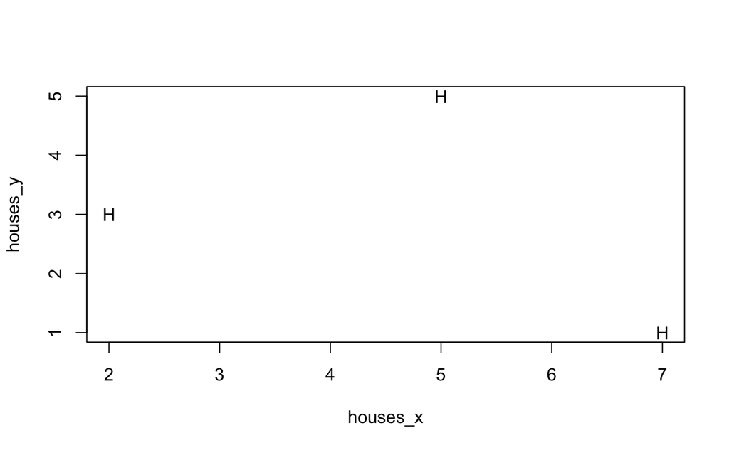

```r
# TODO: WRITE YOUR CODE HERE

plot(houses_x,houses_y,pch = "H")
```

## 1.2. Plotting a Map of the Somewhere School District

Before we get started, let’s first load a dataset in R. To tell R where to look we can give the full filename (e.g. “/Users/jonathanproctor/…myfile.csv”) but that’s a bit cumbersome. To make things easier for us, R has a default place it looks for files called the “working directory”. The working directory tells R where to start looking for files, and then all file names are understood by R to be relative to that place. You can check your working directory using the function `getwd()`. And you can see what’s in your working directory using the function `list.files()`.

```r
getwd()
```

```
[1] "/Users/jefferyliao/Desktop/FRE 430/Lab2_code_data_2026"
```

```r
list.files()
```

```
[1] "closest_school_distances"       "Lab2_data"                      "Lab2.nb.html"
[4] "Lab2.Rmd"                       "Schools_and_closest_houses.pdf"
```

By default, the working directory is set to the location of your Rmd file. You can set your working directory to another place using the `setwd()` function, but note that this will change the working directory for only the current code chunk. Note that when writing file paths if you press tab, Rstudio will show options to auto-complete the file name. To start from the lowest level of files and work up type `“\”` if you are using a Windows Operating System (or `“/”` if using Mac OS or Linux) and then press tab to see what the next level of files is.

Lets try loading a dataset:

```r
df_houses = read.csv("Lab2_data/houses.csv")
```

This loads the data from the file “houses.csv” located in the folder “Lab2_data” within the working directory and assigns it to the variable df_houses. To learn more about the variable we can use the str() function:

```r
str(df_houses)
```

```
'data.frame':   50 obs. of  2 variables:
 $ x_coord_house: num  41.23 5.84 14.99 17.83 48.26 ...
 $ y_coord_house: num  32.07 34.35 1.64 23.84 35.64 ...
```

We can see that the variable is a “data.frame” object. Data frames are one of the most common ways to store data in R. They are two-dimensional arrays where the columns can contain different types of data (e.g. numeric data, character data, binary data). Each column must still contain only one type of data within it though. Each row of the data frame usually represents a single observation or object and each column contains information about that object. Here, each row represents a single house, and the first column indicates the x-coordinate of the house and the second column indicates the y-coordinate of the house. To view the contents of the data frame you can type View(df_houses) in the console. To access columns of the dataframe as individual vectors you can use the “$” command. For example, `df_houses$x_coord_house` would give you the first column of the dataframe. `df_houses[,1]` would give you the same thing.

Now, let’s make the map. Specifically, let’s make a map of the houses and the schools in this area. To do this, first load the school data “schools.csv”. Then plot the houses. When plotting the houses choose a symbol and color for the points. Do the same when adding the schools. Label the axes “X” and “Y” and title the graph “Somewhere School District”. Add a legend to the plot using the “legend” function, ideally in a way that doesn’t cover the points you want to display. Use “?” to learn more about the plot, points, and legend functions as needed to construct the plot.

```r
### TODO YOUR CODE HERE
df_schools = read.csv("Lab2_data/schools.csv")

plot(df_houses$x_coord_house,df_houses$y_coord_house, pch = 8 , col = "red",
     xlab = "X Coords", ylab = "Y Coords", main = "Somewhere School District")
points(df_schools$x_coord_school,df_schools$y_coord_school, pch = 17, col = "yellow")
```

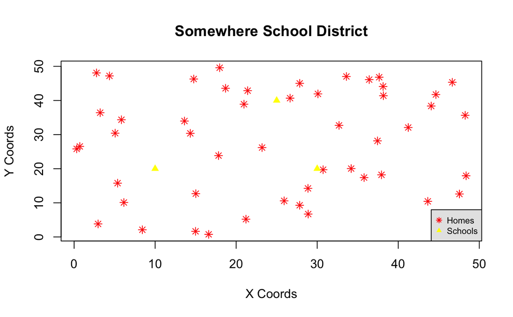

```r
legend("bottomright", c("Homes","Schools"), col = c("red","yellow"), pch = c(8,17),
       cex = 0.7, bg = "gray90")
```

Now your task is to figure out which household should be assigned to which school. I’ll walk you through this.

## 1.3. Compute the distance from house1 to school1 (assume 1 unit in the x or y dimension is 1 km).

Report the distance and the code you used to calculate the distance. (Hint: You should be accessing the x location of house1 by typing `df_houses$x_coord_house[1]`. $a^b$ in R is expressed as `a^b` and you can use `sqrt` for taking the square root.).

```r
### TODO YOUR CODE HERE
dist = sqrt(((df_schools$x_coord_school[1]-df_houses$x_coord_house[1])^2)
            +((df_schools$y_coord_school[1]-df_houses$y_coord_house[1])^2))
```

We can report this more nicely using the `print` and `paste0` commands. For example, if you saved the distance as “dist” you could write:

```r
print(paste0("Distance from house1 to school1 is : ", dist))
```

```
[1] "Distance from house1 to school1 is : 33.4863012568588"
```

```r
# Or if you want just a few significant figures:
print(paste0("Distance from house1 to school1 is : ", round(dist,2)))
```

```
[1] "Distance from house1 to school1 is : 33.49"
```

The `paste0` function here combines together character vectors, or in this case combines a character vector with a scalar (converted to a character in the background), to create a single character vector which is printed.

## 1.4. Now we want to compute the distance of each house to school1.

```r
for(i in 1:5){
  print(paste0("hello, this number is ", i))
}
```

```
[1] "hello, this number is 1"
[1] "hello, this number is 2"
[1] "hello, this number is 3"
[1] "hello, this number is 4"
[1] "hello, this number is 5"
```

The first line tells R to start the first loop with i = 1 and to repeat the loop 5 times (until i reaches 5). The last run of the loop will be the run with the value of i = 5. R runs through the lines after this line in the brackets. The brackets “{}” signal to R that the lines are within the for loop.

Using code that is similar in structure to the loop above, write code to count from 1 to 50 and print “the distance between house {} and school1 is {}”, and then fill in the house number and the distance for each of the 50 houses. If you use the letter i as your counter variable (like the example above), you will need to access the location of house i using `df_houses$x_coord_house[i]` and `df_houses$y_coord_house[i]` inside your loop. (Hint: because you are only looking at school1, you do not want the index of the `df_schools$x_coord_school[1]` and `df_schools$y_coord_school[1]` to be changing inside your loop.)

```r
### TODO: WRITE YOUR CODE HERE

for (i in 1:50){
  distance = sqrt(((df_schools$x_coord_school[1]-df_houses$x_coord_house[i])^2)
        +((df_schools$y_coord_school[1]-df_houses$y_coord_house[i])^2))
  print(paste0("the distance between house ",i, " and school1 is ",distance))
}
```

```
[1] "the distance between house 1 and school1 is 33.4863012568588"
[1] "the distance between house 2 and school1 is 14.9369558118614"
[1] "the distance between house 3 and school1 is 19.021407646333"
[1] "the distance between house 4 and school1 is 8.72045238648754"
[1] "the distance between house 5 and school1 is 41.3335178321331"
[1] "the distance between house 6 and school1 is 38.4340181119831"
[1] "the distance between house 7 and school1 is 26.5503850493589"
[1] "the distance between house 8 and school1 is 20.342233285351"
[1] "the distance between house 9 and school1 is 25.9997758413485"
[1] "the distance between house 10 and school1 is 20.7295699332967"
[1] "the distance between house 11 and school1 is 11.3560779974053"
[1] "the distance between house 12 and school1 is 35.3691628415365"
[1] "the distance between house 13 and school1 is 30.6435481789416"
[1] "the distance between house 14 and school1 is 11.5173562973787"
[1] "the distance between house 15 and school1 is 20.8129950664849"
```

[output cut: 35 more lines]

## 1.5. It’s neat to print the results, but we need to actually store these numbers so that we can compare distances to different schools.

To store these distances, we need to create a new vector that will hold this new information. Do

`dist = array(data = NA, dim = c(50,3))`

to create this new vector. Read the `array` documentation to understand why this command works. In the first row and the first column of the vector, we’ll put the distance between house1 and school1. In the second row and the first column, we’ll put the distance between house2 and school1, etc.

Create this vector. Then, add a command inside your for loop that assigns the distance between house i and school1 to element `dist[i, 1]`. To do this, type something that looks similar to `dist[i, 1] = the_distance_you_calculated_for_house_i_to_school1` inside your loop. This command will replace one of the NAs in the distances vector (at the i-th row and 1-th column) with the distance that you calculated. Now when you run your code, you should end up with an array with 50x3 elements, where the 1st column describes the distances from each house to school1. But the 2nd and the 3rd columns are all NAs, because we haven’t filled in distances to the other schools yet.

```r
### TODO: WRITE YOUR CODE HERE

dist = array(data = NA, dim = c(50,3))
for (i in 1:50){
  dist[i, 1] = sqrt(((df_schools$x_coord_school[1]-df_houses$x_coord_house[i])^2)
        +((df_schools$y_coord_school[1]-df_houses$y_coord_house[i])^2))
}
```

## 1.6. Calculate the distances for the other two schools.

Do the same thing for school2 and school3. You can do this by adding another loop outside or inside the existing loop. You should end up with the array `dist` which stores all the pairwise distances between houses and schools.

```r
### TODO: WRITE YOUR CODE HERE
for (i in 1:50){
  dist[i,2] = sqrt(((df_schools$x_coord_school[2]-df_houses$x_coord_house[i])^2)
        +((df_schools$y_coord_school[2]-df_houses$y_coord_house[i])^2))
  dist[i,3] = sqrt(((df_schools$x_coord_school[3]-df_houses$x_coord_house[i])^2)
        +((df_schools$y_coord_school[3]-df_houses$y_coord_house[i])^2))
}
```

# 1.7. Choosing the closest school.

For each house we need to determine whether it’s closest to school1, school2 or school3. Do this by writing a for loop. Inside of this loop, we will use `if` statements to check which school is closest to each house. An `if` statement evaluates *if* something is `True` or `False`, and if it is true, then it executes a specified command. Here, for each house we will check whether the distance to school1 is shorter than the distance to school2 and school3. If it is, then we know that school1 is the closest and we’ll assign the house to that school.

TODO: Fill in the missing code to check if school 2 is the closest:

```r
#initialize a vector
closest = c()
#for each school
for(i in 1:50){
  #if the distance to school 1 is less than that of school 2 and 3, school 1 is closest
  if( (dist[i,1] <= dist[i,2]) & (dist[i,1] <= dist[i,3]) ){
    closest[i] = 1
  #if the distance to school 2 is less than that of school 1 and 3, school 2 is the closest
  } else if( (dist[i,1] >= dist[i,2]) & (dist[i,2] <= dist[i,3]) ) {
    closest[i] = 2
  #otherwise, school 3 is the closest
  } else {
    closest[i] = 3
  }
}
closest
```

```
 [1] 3 1 1 1 2 3 2 1 2 3 1 2 2 1 3 3 2 2 2 3 2 2 3 2 3 1 2 1 1 1 3 2 3 3 2 2 1 2 2 2 3 1 3 2 1 3 2 2 1 3
```

[Beginning of optional section, the required questions resume after this brief optional section.]

[OPTIONAL SECTION] Oftentimes there are many ways to solve a given problem. Another way to find the shortest distance to the school is to use the `which.min` function. `which.min` tells you which element of a vector is the minimum. For longer vectors this will be much more efficient than comparing each element to the others using if statements. Create a new vector called closest2, as above, and then write a for loop that examines the data in each row of dist and uses `which.min` to determine which school is the closest.

```r
### TODO YOUR CODE HERE
#Find the closest school:

closest2 = c()

for (i in 1:50){
  closest2[i] = which.min(dist[i, ])
}

closest2
```

```
 [1] 3 1 1 1 2 3 2 1 2 3 1 2 2 1 3 3 2 2 2 3 2 2 3 2 3 1 2 1 1 1 3 2 3 3 2 2 1 2 2 2 3 1 3 2 1 3 2 2 1 3
```

[OPTIONAL SECTION] Yet another even shorter way to solve this problem is to use the `apply` function instead of a for loop. Because applying a function to each row or column of a matrix is such a common thing to do, R has a function that allows you to do so in a single line. Use `?apply` to learn how to use the apply function; there are helpful examples towards the end of the description. Save the output of the apply function as closest3.

```r
### TODO YOUR CODE HERE
closet3 = c()
closest3 = apply(dist,1,which.min)
closest3
```

```
 [1] 3 1 1 1 2 3 2 1 2 3 1 2 2 1 3 3 2 2 2 3 2 2 3 2 3 1 2 1 1 1 3 2 3 3 2 2 1 2 2 2 3 1 3 2 1 3 2 2 1 3
```

[OPTIONAL SECTION] We can check whether the elements of two vectors are equal using the `==` command. Note that this is TWO equal signs, using only one would assign the vector on the right side of `=` to the vector on the left side.

```r
closest == closest2
```

```
 [1] TRUE TRUE TRUE TRUE TRUE TRUE TRUE TRUE TRUE TRUE TRUE TRUE TRUE TRUE TRUE TRUE TRUE TRUE TRUE TRUE TRUE
[22] TRUE TRUE TRUE TRUE TRUE TRUE TRUE TRUE TRUE TRUE TRUE TRUE TRUE TRUE TRUE TRUE TRUE TRUE TRUE TRUE TRUE
[43] TRUE TRUE TRUE TRUE TRUE TRUE TRUE TRUE
```

```r
closest2 == closest3
```

```
 [1] TRUE TRUE TRUE TRUE TRUE TRUE TRUE TRUE TRUE TRUE TRUE TRUE TRUE TRUE TRUE TRUE TRUE TRUE TRUE TRUE TRUE
[22] TRUE TRUE TRUE TRUE TRUE TRUE TRUE TRUE TRUE TRUE TRUE TRUE TRUE TRUE TRUE TRUE TRUE TRUE TRUE TRUE TRUE
[43] TRUE TRUE TRUE TRUE TRUE TRUE TRUE TRUE
```

[OPTIONAL SECTION] If you have long vectors and you want to make sure they’re all equal you can use the `all` function to check equality:

```r
all(closest == closest2)
```

```
[1] TRUE
```

```r
all(closest == closest3)
```

```
[1] TRUE
```

If these are not both TRUE, I recommend checking and correcting your work above.

[End of optional section, the rest is required]

Now, let’s plot the data using ggplot2. We’ll go into more detail on how ggplot works in future labs, but for now, know that `ggplot` creates the ggplot object and then you add on details as you go with `+` signs. For example we then add a layer of points related to the houses, and then a layer of points related to the schools. We then specify aesthetic details like the labels. The aesthetic mappings (`aes`) define how variables in the dataset are mapped to visual elements like points, lines, colors, etc — essentially what are your X and Y variables. Try changing some of the colors (`col`) or shapes (`shape`) used below to get a sense of how it works. Usually for quick things, I use the base R `plot` functions and then for pretty maps I use `ggplot` since it has much more flexibility.

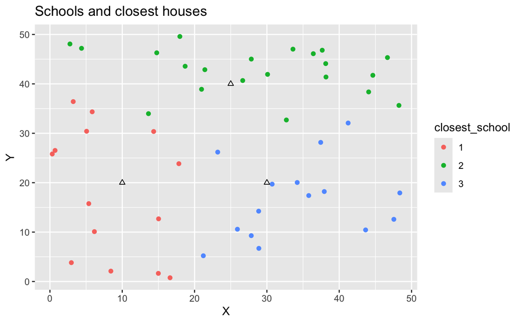

```r
df_houses$closest_school = as.factor(closest)

library(ggplot2)
gg = ggplot() + geom_point(data = df_houses, mapping = aes(x = x_coord_house, y = y_coord_house, col = closest_school)) + geom_point(data = df_schools, mapping = aes(x = x_coord_school, y = y_coord_school), shape = 2) + labs(x = "X", y = "Y", title = "Schools and closest houses")
gg
```

Using the `ggsave` function, save the plot as a pdf to the same folder as the lab. And using the `write.csv` function, save your dataset with the house locations and closest school as well.

```r
### TODO YOUR CODE HERE

ggsave("Schools_and_closest_houses.pdf",width = 10, height= 10)

write.csv(dist,"closest_school_distances")
```

# 2. Functions

## Introducing functions

So far we have focused on code that goes down a sequence of commands as if we typed them in that order in the command line. But sometimes we find ourselves typing similar things, doing the same kind of calculation over and over again. In these cases, it’s useful to write a function so we don’t have to keep retyping the same sequence of commands and debugging it each time. We can write a function that solves the same problem in a “general case” and then we don’t have to think very hard each time we want to do a related operation, we just call the function. Writing functions can also help us avoid mistakes and help us debug code faster, since once we make sure the function works then we don’t have to debug it each time we call it (so long as we debug it well the first time).

R already has many functions that we have been using all along; however, you can design new functions that can be called in the same way but have new functionality. Here’s how a function can be defined in R:

```r
add = function(a, b){
    ### This function performs addition.

    ###Args:
        #a, b (float): numbers to be added.

    ###Returns:
        #float: the sum of a and b

    summation = a + b

    return (summation)
}
```

Note: When you run the `add = function(...)` code, the function is defined but not executed (it’s like you purchased a blender, but didn’t put in anything yet). You have to then call it with inputs to get the outputs (you have to then put in fruits and milk to get your smoothie).

```r
add(a = 2, b = 5)
```

```
[1] 7
```

The first line of the function definition tells R that this is a function, named add, that takes in two arguments. Arguments are assigned to the named local variables in a function body. These variable names are only used within the function, so if you were to type `a` elsewhere hoping to use that variable, you won’t find it. Once the function is called and finishes execution, all of the variables that are used in the function are erased and it only outputs the objects that you specify it must output (using `return`). To see this, try typing “summation” into your console. Despite being used in the function above it is not in your global environment (functions have environments of their own). Remember that once anything is returned, you exit the function (all the following commands aren’t be executed).

The next several lines of code are called “docstrings”. Docstrings are incredibly important. They tell the users of this function (most likely your future self) what this function does, and specify, e.g., the input/output of the function. You may want to use a function several years from now and it’s much easier to just read a clear documentation to remember how the code works rather than to read the code itself.

The code between the docstring and `return` is what the function is actually doing. In this simple case, it is adding two variables.

Following this example, write a function called `calc_dist_3D` that intakes two three-dimensional coordinates (e.g. `coord1 = c(1,2,3)` and calculates the euclidean distance between them. Make sure to describe what your function is and how to use it.

```r
### TODO YOUR CODE HERE

calc_dist_3D = function(coord1, coord2){

  ### This function takes the euclidean distance between two three-dimensional coordinates
  ### Args: coord1 (a,b,c) and coord2 (a,b,c)
  ### returns:
      # float: the distance

  dist = sqrt(sum((coord2-coord1)^2))
  return (dist)
}
```

**Testing Your Functions**

**You should always, always, always test your functions.** Test your functions with simple, intuitive tests. For example, run the following cells and convince yourself that your function is behaving as expected.

```r
#This should be true!
calc_dist_3D(coord1 = c(0,0,0), coord2 = c(0,0,1) ) == 1
```

```
[1] TRUE
```

```r
#And this!
calc_dist_3D(coord1 = c(0,0,0), coord2 = c(0,3,4) ) == 5
```

```
[1] TRUE
```

Congrats on finishing lab 2! You’ve learned the fundamentals of some of the most important aspects of R: for loops, if statements, functions, and plotting. Nice work! Please submit your lab by uploading it to Canvas as YOURLASTNAME.Rmd and YOURLASTNAME.html. Remember to re-run the full notebook if needed prior to submission.